# **Assignment**

This assignment will be described in multiple parts. You will need to write a report that answers the questions detailed below. Ultimately, you will need to complete the entire assignment in a single R markdown document that can be processed by knitr and be transformed into an HTML file.

Throughout your report make sure you always include the code that you used to generate the output you present. When writing code chunks in the R markdown document, always use echo = TRUE so that someone else will be able to read the code. This assignment will be evaluated via peer assessment so it is essential that your peer evaluators be able to review the code for your analysis.

For the plotting aspects of this assignment, feel free to use any plotting system in R (i.e., base, lattice, ggplot2)

| Assignment #1 |
| --- |

Load data into the “pasos” dataframe

```r
pasos <- read.csv(file = "activity.csv", header = TRUE, sep = ",")
summary(pasos)
```

```
##      steps                date          interval
##  Min.   :  0.00   2012-10-01:  288   Min.   :   0.0
##  1st Qu.:  0.00   2012-10-02:  288   1st Qu.: 588.8
##  Median :  0.00   2012-10-03:  288   Median :1177.5
##  Mean   : 37.38   2012-10-04:  288   Mean   :1177.5
##  3rd Qu.: 12.00   2012-10-05:  288   3rd Qu.:1766.2
##  Max.   :806.00   2012-10-06:  288   Max.   :2355.0
##  NA's   :2304     (Other)   :15840
```

Calculate the total number of steps taken per day and store the information into the sumpasospordia variable

```r
sumpasospordia <- aggregate(pasos$steps, by = list(pasos$date), sum, na.rm = TRUE)
names(sumpasospordia) <- c("date", "steps")
sumpasospordia
```

```
##          date steps
## 1  2012-10-01     0
## 2  2012-10-02   126
## 3  2012-10-03 11352
## 4  2012-10-04 12116
## 5  2012-10-05 13294
## 6  2012-10-06 15420
## 7  2012-10-07 11015
## 8  2012-10-08     0
## 9  2012-10-09 12811
## 10 2012-10-10  9900
## 11 2012-10-11 10304
## 12 2012-10-12 17382
## 13 2012-10-13 12426
## 14 2012-10-14 15098
```

[output cut: 47 more lines]

Make a histogram of the total number of steps taken each day.

If you do not understand the difference between a histogram and a barplot, research the difference between them:

*“Histograms are used to show distributions of variables while bar charts are used to compare variables.”Histograms plot quantitative data with ranges of the data grouped into bins or intervals while bar charts plot categorical data. " histograms are used to show distributions of variables while bar charts are used to compare variables. Histograms plot binned quantitative data while bar charts plot categorical data. Bars can be reordered in bar charts but not in histograms." “source Naomi Robins, A Histogram is NOT a barchart @ forbes 1/04/2012.*

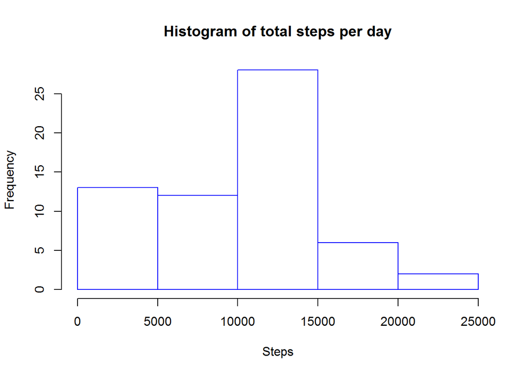

```r
hist(sumpasospordia$steps, border = "blue", main = "Histogram of total steps per day", xlab="Steps")
```

Calculate and report the mean and median of the total number of steps taken per day

```r
meantotalpasosdia <- round(mean(sumpasospordia$steps, na.rm = TRUE),4)
meantotalpasosdia
```

```
## [1] 9354.229
```

```r
mediantotalpasosdia <- median(sumpasospordia$steps, na.rm = TRUE)
mediantotalpasosdia
```

```
## [1] 10395
```

The mean is 9354.2295 from the total steps by day.

The median is 10395 from the total steps by day.

Make a time series plot (i.e. type = “l”) of the 5-minute interval (x-axis) and the average number of steps taken, averaged across all days (y-axis)

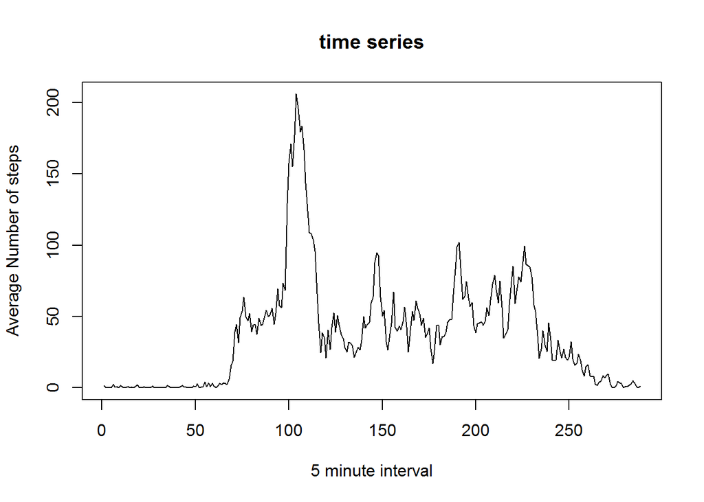

```r
meanpasosint <- tapply(pasos$steps, pasos$interval, function(x) mean(x, na.rm=T))
ejex <- 1:length(meanpasosint)
plot( ejex, meanpasosint, type = "l", main="time series", xlab="5 minute interval", ylab="Average Number of steps")
```

Create a vector to easily indentify weekdays and weekends

```r
semana <- c("Monday", "Tuesday", "Wednesday", "Thursday", "Friday")
finde <- c("Saturday", "Sunday")
```

Which 5-minute interval, on average across all the days in the dataset, contains the maximum number of steps?

```r
meanmayor <- max(meanpasosint)
intemayor <- meanpasosint[ejex[meanpasosint==meanmayor]]
intemayor
```

```
##      835
## 206.1698
```

The 5-minute interval is 835 with the high average number of steps of 206.1698113

Calculate and report the total number of missing values in the dataset (i.e. the total number of rows with NAs)

```r
cantidadpasosna <-sum(is.na(pasos))
cantidadpasosna
```

```
## [1] 2304
```

Total number of NAs is 2304.

Devise a strategy for filling in all of the missing values in the dataset. Strategy: use the mean accross all days for the 5-min interval where NA is found.

Create a new dataset that is equal to the original dataset but with the missing data filled in.

```r
copiapasos <- pasos
```

Apply strategy to fill in

```r
for (i in 1:nrow(pasos)) {
    if (is.na(pasos$steps[i])) {
        copiapasos$steps[i] <- meanpasosint[as.character(pasos$interval[i])]
    }
}
```

Make a histogram of the total number of steps taken each day and Calculate and report the mean and median total number of steps taken per day. Same as above with different data frame.

```r
sumpasospordia2 <- aggregate(copiapasos$steps, by = list(copiapasos$date), sum)
names(sumpasospordia2) <- c("date", "steps")
sumpasospordia2
```

```
##          date    steps
## 1  2012-10-01 10766.19
## 2  2012-10-02   126.00
## 3  2012-10-03 11352.00
## 4  2012-10-04 12116.00
## 5  2012-10-05 13294.00
## 6  2012-10-06 15420.00
## 7  2012-10-07 11015.00
## 8  2012-10-08 10766.19
## 9  2012-10-09 12811.00
## 10 2012-10-10  9900.00
## 11 2012-10-11 10304.00
## 12 2012-10-12 17382.00
## 13 2012-10-13 12426.00
## 14 2012-10-14 15098.00
```

[output cut: 47 more lines]

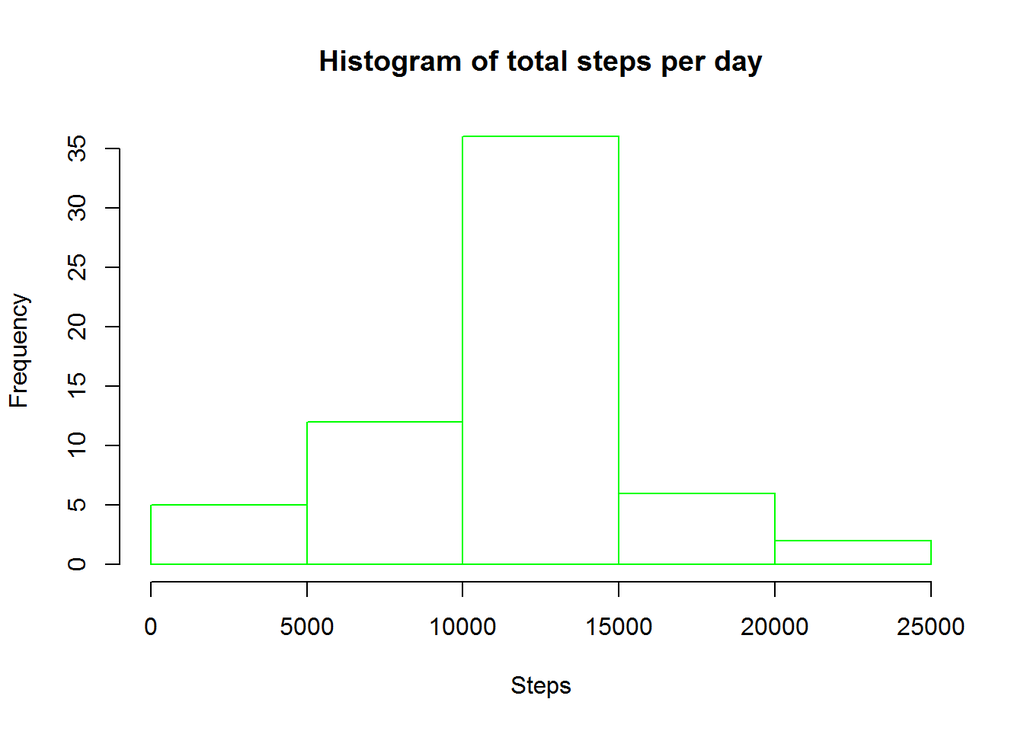

```r
hist(sumpasospordia2$steps, border = "green", main = "Histogram of total steps per day", xlab="Steps")
```

```r
meantotalpasosdia2 <- round(mean(sumpasospordia2$steps),4)
meantotalpasosdia2
```

```
## [1] 10766.19
```

```r
mediantotalpasosdia2 <- round(median(sumpasospordia2$steps),4)
mediantotalpasosdia2
```

```
## [1] 10766.19
```

Mean and median are differente from the previuos calculations wich included the NA values.

Get the info about the weekdays and weekends dates

```r
copiapasos$date <- as.Date(copiapasos$date)
copiapasos$day <- weekdays(copiapasos$date)
copiapasos$day[copiapasos$day %in% semana] <- "weekday"
copiapasos$day[copiapasos$day %in% finde] <- "weekend"
copiapasos$day <- factor(copiapasos$day)
```

Split the data into weekend and weekday data

```r
tipodia <- split(copiapasos, copiapasos$day)
infodiasemana <- tipodia$weekday
infodiafinde <- tipodia$weekend
```

Obtain the means by each type of day based on the intervals

```r
meandiassemana <- tapply(infodiasemana$steps, infodiasemana$interval, function(x) mean(x, rm.na=TRUE))
meandiafinde <- tapply(infodiafinde$steps, infodiafinde$interval, function(x) mean(x, rm.na=TRUE))

rango <- 1:length(meandiassemana)
```

Plot comparison graphs between weekend data and weekday data

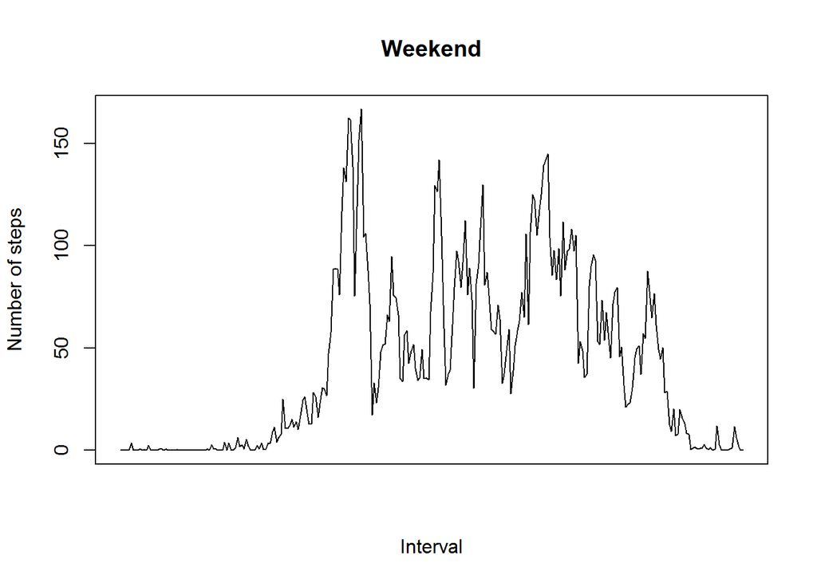

```r
plot(rango, meandiafinde, type="l", main="Weekend", xlab="Interval", ylab="Number of steps", xaxt="n")
```

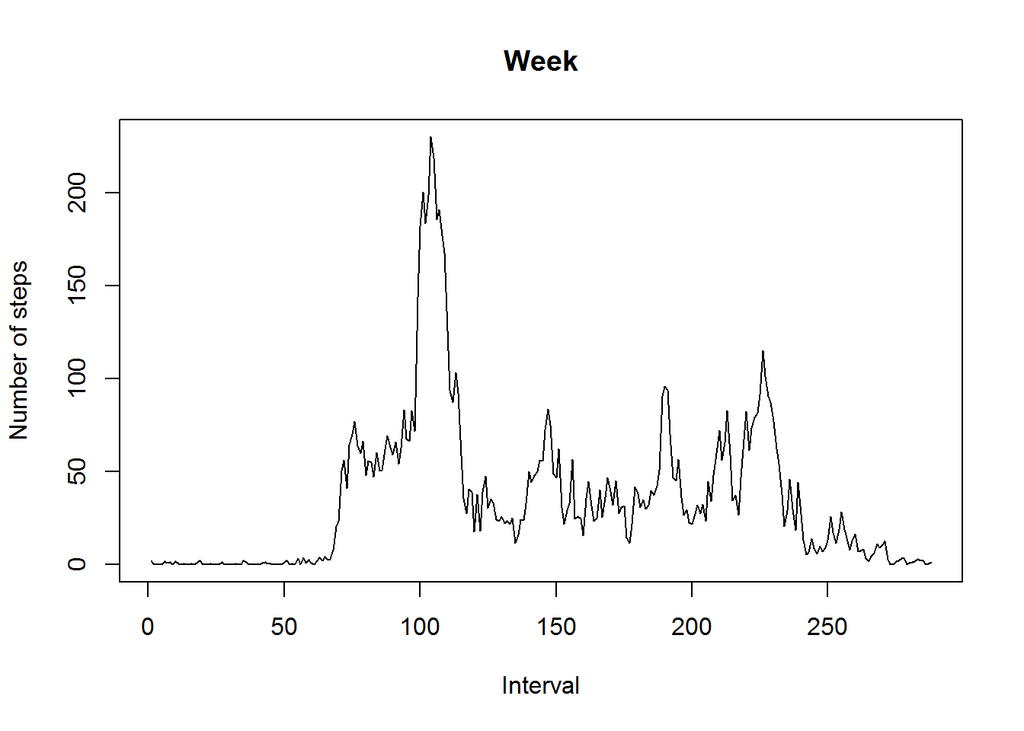

```r
plot(rango, meandiassemana, type="l", main="Week", xlab="Interval", ylab="Number of steps")
```